# Analysis Plan

2022-08-26

```r
mytheme <- function (palette = "black_and_white", base_size = 14, base_family = "sans",
                     base_fontface = "plain", base_line_size = base_size/20, base_rect_size = base_size/14,
                     axis_text_angle = 0, border = FALSE) {

  is_bool <- function(x) {
    is_logical(x, n = 1) && !is.na(x)
  }
  angle <- axis_text_angle[1]
   if (!angle %in% c(0, 45, 90, 270))
     stop(sprintf("'axis_text_angle' must be one of [%s]",
                  paste(c(0, 45, 90, 270), collapse = ", ")), ".\nFor other angles, use the guide_axis() function in ggplot2 instead",
          call. = FALSE)
   if (!palette %in% names(ggprism::ggprism_data$themes)) {
     stop("The palette ", paste(palette), " does not exist.\n         See names(ggprism_data$themes) for valid palette names")
   }
   colours <- tibble::deframe(ggprism::ggprism_data$themes[[palette]])
   if (!is_bool(border)) {
     stop("border must be either: TRUE or FALSE")
   }
   else {
     if (border) {
       panel.border <- element_rect(fill = NA)
       axis.line <- element_blank()
     }
     else if (!border) {
       panel.border <- element_blank()
       axis.line <- element_line()
     }
   }
   t <- theme(line = element_line(colour = colours["axisColor"],
                                  size = base_line_size, linetype = 1, lineend = "square"),
              rect = element_rect(fill = "white", colour = colours["axisColor"],
                                  size = base_rect_size, linetype = 1), text = element_text(family = base_family,
                                                                                            face = base_fontface, colour = colours["graphTitleColor"],
                                                                                            size = base_size, lineheight = 0.9, hjust = 0.5,
                                                                                            vjust = 0.5, angle = 0, margin = margin(), debug = FALSE),
              prism.ticks.length = unit(base_size/50, "pt"), axis.line = axis.line,
              axis.line.x = NULL, axis.line.y = NULL, axis.text = element_text(size = rel(0.95),
                                                                               colour = colours["axisLabelColor"]), axis.text.x = element_text(margin = margin(t = 0.8 *
                                                                                                                                                                 base_size/4), angle = axis_text_angle, hjust = ifelse(axis_text_angle %in%
                                                                                                                                                                                                                         c(45, 90, 270), 1, 0.5), vjust = ifelse(axis_text_angle %in%
                                                                                                                                                                                                                                                                   c(0, 90, 270), 0.5, 1)), axis.text.x.top = element_text(margin = margin(b = 0.8 *
                                                                                                                                                                                                                                                                                                                                             base_size/4), vjust = 0), axis.text.y = element_text(margin = margin(r = 0.5 *
                                                                                                                                                                                                                                                                                                                                                                                                                    base_size/4), hjust = 1), axis.text.y.right = element_text(margin = margin(l = 0.5 *
                                                                                                                                                                                                                                                                                                                                                                                                                                                                                                 base_size/4), hjust = 0), axis.ticks = element_line(),
              axis.ticks.length = unit(3, "points"), axis.ticks.length.x = NULL,
              axis.ticks.length.x.top = NULL, axis.ticks.length.x.bottom = NULL,
              axis.ticks.length.y = NULL, axis.ticks.length.y.left = NULL,
              axis.ticks.length.y.right = NULL, axis.title = element_text(colour = colours["axisTitleColor"]),
              axis.title.x = element_text(margin = margin(t = base_size *
                                                            0.6), vjust = 1), axis.title.x.top = element_text(margin = margin(b = base_size *
                                                                                                                                0.6), vjust = 0), axis.title.y = element_text(angle = 90,
                                                                                                                                                                              margin = margin(r = base_size * 0.6), vjust = 1),
              axis.title.y.right = element_text(angle = -90, margin = margin(l = base_size *
                                                                               0.6), vjust = 0), legend.background = element_blank(),
              legend.spacing = unit(base_size, "pt"), legend.spacing.x = NULL,
              legend.spacing.y = NULL, legend.margin = margin(base_size/2,
                                                              base_size/2, base_size/2, base_size/2), legend.key = element_blank(),
              legend.key.size = unit(1.2, "lines"), legend.key.height = NULL,
              legend.key.width = unit(base_size * 1.8, "pt"), legend.text = element_text(size = rel(0.8),
                                                                                         face = "plain"), legend.text.align = NULL, legend.title = element_blank(),
              legend.title.align = NULL, legend.position = "right",
              legend.direction = NULL, legend.justification = "center",
              legend.box = NULL, legend.box.margin = margin(0, 0, 0,
                                                            0, "cm"), legend.box.background = element_blank(),
              legend.box.spacing = unit(base_size, "pt"), panel.background = element_rect(fill = ifelse(palette ==
                                                                                                          "office", colours["plottingAreaColor"], NA), colour = NA),
              panel.border = panel.border, panel.grid = element_blank(),
              panel.grid.minor = element_blank(), panel.spacing = unit(base_size/2,
                                                                       "pt"), panel.spacing.x = NULL, panel.spacing.y = NULL,
              panel.ontop = FALSE, strip.background = element_blank(),
              strip.text = element_text(colour = colours["axisTitleColor"],
                                        size = rel(0.8), margin = margin(base_size/2.5, base_size/2.5,
                                                                         base_size/2.5, base_size/2.5)), strip.text.x = element_text(margin = margin(b = base_size/3)),
              strip.text.y = element_text(angle = -90, margin = margin(l = base_size/3)),
              strip.text.y.left = element_text(angle = 90), strip.placement = "inside",
              strip.placement.x = NULL, strip.placement.y = NULL, strip.switch.pad.grid = unit(base_size/4,
                                                                                               "pt"), strip.switch.pad.wrap = unit(base_size/4,
                                                                                                                                   "pt"), plot.background = element_rect(fill = colours["pageBackgroundColor"],
                                                                                                                                                                         colour = NA), plot.title = element_text(size = rel(1.2),
                                                                                                                                                                                                                 hjust = 0.5, vjust = 1, margin = margin(b = base_size)),
              plot.title.position = "panel", plot.subtitle = element_text(hjust = 0.5,
                                                                          vjust = 1, margin = margin(b = base_size/2)), plot.caption = element_text(size = rel(0.8),
                                                                                                                                                    hjust = 1, vjust = 1, margin = margin(t = base_size/2)),
              plot.caption.position = "panel", plot.tag = element_text(size = rel(1.2),
                                                                       hjust = 0.5, vjust = 0.5), plot.tag.position = "topleft",
              plot.margin = margin(base_size/2, base_size/2, base_size/2,
                                   base_size/2), complete = TRUE)
   ggprism::ggprism_data$themes[["all_null"]] %+replace% t
 }
```

```r
# Load libraries
library(dplyr)
library(purrr)
library(stringr)
library(ggplot2)
library(ggpubr)
library(jcolors)
library(cowplot)
library(ggprism)
library(tidybayes)
library(reshape2)
library(parallel)
library(rstan)


effect_size = c("Paper Effect Size", "Paper Effect Size/2", "Paper Effect Size/3",
    "Paper Effect Size/4")
# Functions
psoftmax <- function(b) exp(c(0, b))/sum(exp(c(0, b)))

words_replace <- function(variable, words_to_replace, replace_with = "") {

    library(dplyr)
    if (!require(dplyr)) {
        install.packages("dplyr")
        library(dplyr)
    }

    # variable <- enquo(variable) var <- select(data, !!variable) %>% .[,]

    if (!is.character(variable))
        variable <- as.character(variable)

    for (word_i in 1:length(words_to_replace)) {
        word_to_rm_index <- which(str_detect(variable, fixed(words_to_replace[word_i])))

        if (any(word_to_rm_index)) {
            words_to_replace_i <- words_to_replace[word_i]
            new_words <- sapply(seq_along(word_to_rm_index), function(i) {
                variable[word_to_rm_index][i] <- gsub(words_to_replace_i, replace_with,
                  variable[word_to_rm_index][i], fixed = TRUE)
            })
            variable[word_to_rm_index] <- new_words
        } else {
            warning(paste0("Sting '", words_to_replace, "' not found"))
        }
    }

    return(variable)
}

seq_vector <- function(x) {
    idx <- c(which(diff(x) != 0), length(x))
    time <- c(idx[1], diff(idx))
    rep(x = 1:length(idx), times = time)
}

# Load data
data_short <- readRDS("../Pilot/Short Version/Data/data_short.rds")$data %>%
    mutate(subject = 1:n()) %>%
    rename(age = Age., A3 = A3.)

questions <- readRDS("../Pilot/Short Version/Data/data_short.rds")$question

# ----- Mental Accounting ----- # Remove final questionnaires
data_short_MA <- data_short[, -(48:75)]
# Remove response time
idx_time <- str_detect(names(data_short_MA), "time_")
data_short_MA <- data_short_MA[, !idx_time]

data_short_MA <- data_short_MA %>%
    rename_with(~gsub(".", "", .x, fixed = TRUE)) %>%
    rename_with(toupper, .cols = -contains("subject"))

n_sbj <- nrow(data_short_MA)
```

## Introduction

To test the replicability of the effects reported in the original papers we will run Bayesian modeling. We analyze the pilot data (short version) following the same procedure that we will follow to analyze the experimental data.

## Mr. A vs Mr. B2

We analyze the data from the first study (“MrAB” scenarios) using a Bayesian binomial mixture regression model. We fit this model first to estimate the probability of choosing option A or B for each scenario and second, to estimate the conditional probability of choosing option A for each scenario.

#### (Short) Pilot Data

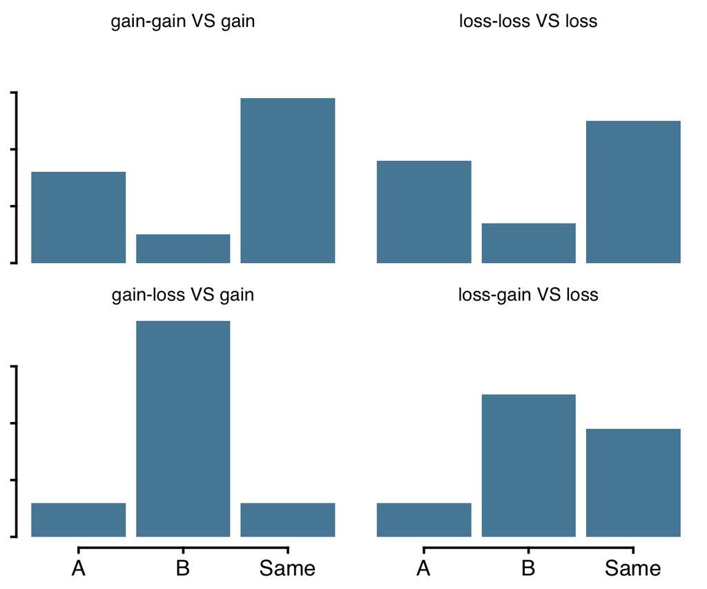

```r
# ---------- Mr. A vs Mr. B2 Scenario ---------- #

# Coding legend: response: 0 (Happier/More upset); 1 (Less Happy/Less upset) 2
# (No difference)

# Create dataframe scenario 1
data_s1 <- data_short %>%
    select(subject, contains("A", ignore.case = FALSE)) %>%
    # Recode response
mutate(`gain-gain VS gain` = case_when(A1 == "A" ~ 0, A1 == "B" ~ 1, T ~ 2), `loss-loss VS loss` = case_when(A2 ==
    "A" ~ 0, A2 == "B" ~ 1, T ~ 2), `gain-loss VS gain` = case_when(A3 == "A" ~ 0,
    A3 == "B" ~ 1, T ~ 2), `loss-gain VS loss` = case_when(A4 == "A" ~ 0, A4 == "B" ~
    1, T ~ 2)) %>%
    select(-contains("A", ignore.case = FALSE)) %>%
    melt(id.var = "subject", variable.name = "scenario", value.name = "response") %>%
    mutate(scenario_group = ifelse(scenario == "gain-gain VS gain" | scenario ==
        "gain-loss VS gain", "gain", "loss"))

data_s1 %>%
    ggplot(aes(response)) + geom_bar(aes(y = (..count..)/sum(..count..)), fill = jcolors::jcolors(palette = "pal6")[1]) +
    mytheme() + theme(legend.position = "none", axis.title.y = element_blank(), axis.text.y = element_blank()) +
    scale_fill_brewer(palette = "Set1") + scale_y_continuous(labels = scales::percent,
    guide = "prism_offset") + scale_x_continuous(guide = "prism_offset", breaks = 0:2,
    labels = c("A", "B", "Same")) + labs(y = NULL, x = NULL) + facet_wrap(~scenario)
```

#### Questions

**Gain-Gain VS Gain**  
Mr. A was given two tickets to the Regional lottery. He won $50 in one lottery and $25 in the other.  
Mr. B was given a ticket to a single, larger Regional lottery. He won $75.  
Who is happier?

A/B/No difference

**Loss-Loss VS Loss**  
Mr. A received a letter from the IRS saying that he made a minor arithmetical mistake on his tax return and owed $100. He received a similar letter the same day from his state income tax authority saying he owed $50. There were no other repercussions from either mistake.  
Mr. B received a letter from the IRS saying he made a minor arithmetical mistake on his tax return and owed $150. There were no other repercussions from this mistake.  
Who more upset?

A/B/No difference

**Gain-Loss VS Gain**  
Mr. A bought his first National lottery ticket and won $100. Also, in a freak accident, he damaged the rug in his apartment and had to pay the landlord $80.  
Mr. B bought his first National lottery ticket and won $20.  
Who is happier?

A/B/No difference

**Loss-Gain VS Loss**  
Mr. A’s car was damaged in a parking lot. He had to spend $200 to repair the damage. The same day the car was damaged, he won $25 in the office holiday raffle.  
Mr. B’s car was damaged in a parking lot. He had to spend $175 to repair the damage.  
Who is more upset?

A/B/No difference

#### Stan Code

```stan
functions {
  /*
   * Args:
   *   y:  response value 0: A, 1: B, 2: No difference
   *   ds: different (0|1) - same (2) probability
   *   cA: conditional (different) A probability
   * Returns:
   *   a scalar to be added to the log posterior
   */
   real mental_accounting_lpdf(real y,  real ds, real cA) {
     if (y == 0) { // Stay (Explore)
       return bernoulli_lpmf(1 | ds) + bernoulli_lpmf(1 | cA);
     } else if (y == 1) { // Switch (Explore)
       return bernoulli_lpmf(1 | ds) + bernoulli_lpmf(0 | cA);
     } else { // Select
       return bernoulli_lpmf(0 | ds);
     }
   }
}

data {
  int<lower=1> N;  // total number of observations
  vector[N] Y;  // response variable
  int<lower=1> K_ds;  // number of population-level effects
  matrix[N, K_ds] X_ds;  // population-level design matrix
  int<lower=1> K_cA;  // number of population-level effects
  matrix[N, K_cA] X_cA;  // population-level design matrix

  int prior_only;  // should the likelihood be ignored?
}
parameters {
  vector[K_ds] b_ds;  // population-level effects
  vector[K_cA] b_cA;  // population-level effects
}

transformed parameters {
}

model {
  // likelihood including constants
  if (!prior_only) {
    // initialize different - same linear predictor term
    vector[N] ds = X_ds * b_ds;
    // initialize linear predictor term
    vector[N] cA = X_cA * b_cA;

    for (n in 1:N) {
      // apply the inverse link function
      ds[n] = inv_logit(ds[n]);
    }
    for (n in 1:N) {
      // apply the inverse link function
      cA[n] = inv_logit(cA[n]);
    }
    for (n in 1:N) {
      target += mental_accounting_lpdf(Y[n] | ds[n], cA[n]);
    }
  }
  // priors including constants
  target += normal_lpdf(b_ds | 0, 5);
  target += normal_lpdf(b_cA | 0, 5);
}
```

```
functions {
  /*
   * Args:
   *   y:  response value 0: A, 1: B, 2: No difference
   *   ds: different (0|1) - same (2) probability
   *   cA: conditional (different) A probability
   * Returns:
   *   a scalar to be added to the log posterior
   */
   real mental_accounting_lpdf(real y,  real ds, real cA) {
     if (y == 0) { // Stay (Explore)
       return bernoulli_lpmf(1 | ds) + bernoulli_lpmf(1 | cA);
     } else if (y == 1) { // Switch (Explore)
       return bernoulli_lpmf(1 | ds) + bernoulli_lpmf(0 | cA);
     } else { // Select
       return bernoulli_lpmf(0 | ds);
     }
   }
}

data {
  int<lower=1> N;  // total number of observations
  vector[N] Y;  // response variable
  int<lower=1> K_ds;  // number of population-level effects
  matrix[N, K_ds] X_ds;  // population-level design matrix
  int<lower=1> K_cA;  // number of population-level effects
  matrix[N, K_cA] X_cA;  // population-level design matrix

  int prior_only;  // should the likelihood be ignored?
}
parameters {
  vector[K_ds] b_ds;  // population-level effects
  vector[K_cA] b_cA;  // population-level effects
}

transformed parameters {
}

model {
  // likelihood including constants
  if (!prior_only) {
    // initialize different - same linear predictor term
    vector[N] ds = X_ds * b_ds;
    // initialize linear predictor term
    vector[N] cA = X_cA * b_cA;

    for (n in 1:N) {
      // apply the inverse link function
      ds[n] = inv_logit(ds[n]);
    }
    for (n in 1:N) {
      // apply the inverse link function
      cA[n] = inv_logit(cA[n]);
    }
    for (n in 1:N) {
      target += mental_accounting_lpdf(Y[n] | ds[n], cA[n]);
    }
  }
  // priors including constants
  target += normal_lpdf(b_ds | 0, 5);
  target += normal_lpdf(b_cA | 0, 5);
}
```

#### Fit

```r
# ---- Fit Model ---- #
library(rstan)
library(tidybayes)
options(mc.cores = 4)
rstan_options(auto_write = TRUE)

# ------------- ~ scenario ------------- #
# Create Stan Data
X <- model.matrix(~ 0 + scenario, data_s1 %>% filter)

#Stan Data
stan_data <- list(
    N        = nrow(data_s1),
    Y        = data_s1$response,
    X_ds     = X,
    X_cA     = X,
    K_ds     = ncol(X),
    K_cA     = ncol(X),

    N_sbj    = n_sbj,
    J_sbj    = data_s1$subject,

    prior_only = 0
  )

# Fit the model
fit_S1 <- rstan::sampling(mixture_scenario_1,
                          iter = 2000,
                          cores = 4,
                          data = stan_data,
                          save_warmup = FALSE)
```

**Plot Model Posteriors**

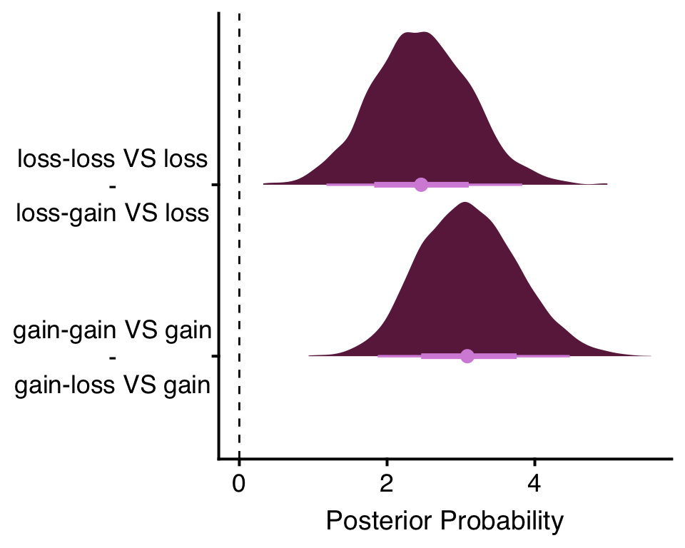

```r
draws <- extract(fit_S1)
colnames(draws$b_ds) <- words_replace(colnames(X), "scenario")
colnames(draws$b_cA) <- words_replace(colnames(X), "scenario")
df <- as.data.frame(draws$b_cA)

rbind(data.frame(post = with(df, `gain-gain VS gain` - `gain-loss VS gain`), effect = "gain-gain VS gain\n-\ngain-loss VS gain"),
    data.frame(post = with(df, `loss-loss VS loss` - `loss-gain VS loss`), effect = "loss-loss VS loss\n-\nloss-gain VS loss")) %>%
    ggplot(aes(x = post, y = effect)) + stat_halfeye(fill = jcolors::jcolors(palette = "pal8")[6],
    color = jcolors::jcolors(palette = "pal8")[12]) + mytheme() + theme(axis.text.y = NULL) +
    geom_vline(xintercept = 0, linetype = 2) + labs(y = NULL, x = "Posterior Probability")
```

## The Sold-Out Ticket

#### (Short) Pilot Data

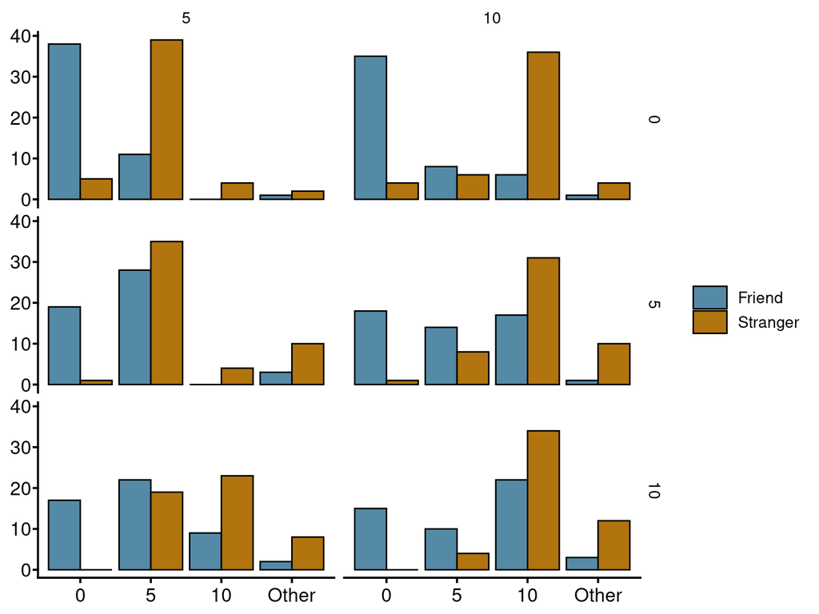

```r
# --------- Coding legend: --------- #
# -- Dependent Variable -- #
# response: 0
#           5
#           10
#           Other
# -- Explanatory Variables -- #
# cost: 0, 5, 10 (defined as p in Thaler 1985)
#      [cost influence the "fair price" (p_star), which is operationalized
#       with the price asked to a friend]
# market_value : 5, 10
# buyer: friend (proxy for a fair price), stranger


# Create dataframe scenario 2
df <- data_short_MA %>%
  select(contains('B', ignore.case =  F))

col_names <- names(df)
cost <- rep(c(0, 5, 10), each=2)
market_value <- rep(c(5, 10), 3)
col_idx <- seq(1,ncol(df),2)
df1 <- map_df(seq_along(col_idx), function(i){

  data.frame( response = c(df[,col_names[col_idx[i]]], df[,col_names[col_idx[i]+1]]),
              cost = cost[i],
              market_value = market_value[i],
              buyer = c(rep('Friend', n_sbj), rep('Stranger', n_sbj)) )

})

data_s2 <- df1 %>%
  mutate(response=ifelse(response%in%unique(cost), response, 'Other'),
         response = factor(response, levels = c('0', '5', '10', 'Other')))

data_s2%>%
  group_by(cost, market_value, buyer) %>%
  count(response, .drop = F) %>%
  ggplot(aes(response, n, fill=buyer)) +
  geom_bar(stat="identity", position=position_dodge(), color="black") +
  mytheme() +
  scale_fill_jcolors(palette = 'pal6') +
  labs(y=NULL, x=NULL) +
  facet_grid(cost~market_value)
```

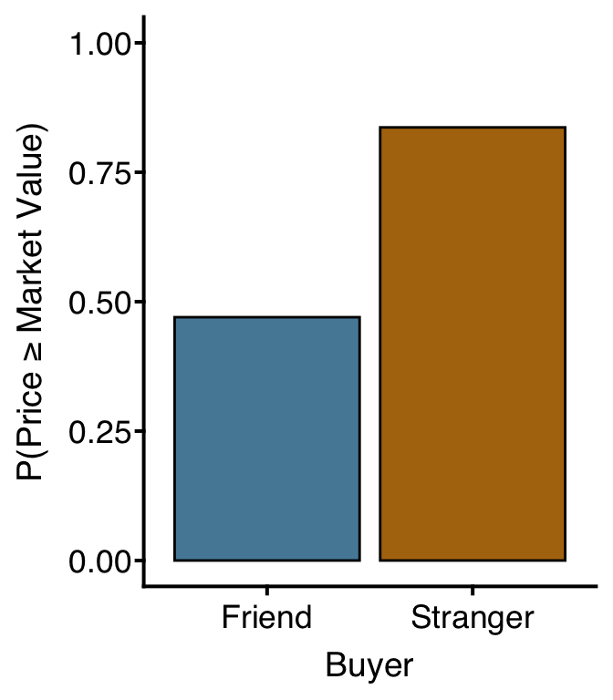

```r
data_s2 <- df1 %>%
    mutate(response = ifelse(response >= market_value, 1, 0))

data_s2 %>%
    group_by(buyer) %>%
    summarise(m = mean(response)) %>%
    ggplot(aes(buyer, m, fill = buyer)) + geom_bar(stat = "identity", position = position_dodge(),
    color = "black") + scale_fill_jcolors(palette = "pal6") + labs(y = "P(Price ≥ Market Value)",
    x = "Buyer") + mytheme() + theme(legend.position = "none") + scale_y_continuous(limits = 0:1)
```

#### Questions

You are going to a sold-out game of your favorite local sport-team, and you have an extra ticket. The price marked on the ticket is $5 but [you were given your tickets for free by a friend / which is what you paid for each ticket / but you paid $10 for each ticket when you bought them from another student].  
You want to get rid of the extra ticket and you know the going price is $5. You find someone who wants the ticket. There is no law against charging more than the price marked on the ticket.

What price do you ask for if…  
a) He is a friend  
b) He is a stranger

What would you have said if you found out that the going market price was $10 instead?  
a) He is a friend  
b) He is a stranger

#### Stan Code

```r
bernoulli_scenario_2 <- rstan::stan_model("bernoulli_scenario_4.stan")
```

```
data {
  int<lower=1> N;  // total number of observations
  int Y[N];  // response variable
  int<lower=1> K;  // number of population-level effects
  matrix[N, K] X;  // population-level design matrix

  int prior_only;  // should the likelihood be ignored?
}

parameters {
  vector[K] b;  // population-level effects
}

transformed parameters {
}

model {
  // likelihood including constants
  if (!prior_only) {
    vector[N] mu = X * b;
    target += bernoulli_logit_lpmf(Y | mu);
  }
  // priors including constants
  target += normal_lpdf(b | 0, 5);
}
```

#### Fit

```r
# Create Stan Data
X <- model.matrix(~ buyer, data_s2)

#Stan Data
stan_data <- list(
  N       = nrow(data_s2),
  Y       = data_s2$response,
  K       = ncol(X),
  X       = X,

  prior_only = 0
)

# Fit the model
fit_S2 <- rstan::sampling(bernoulli_scenario_2,
                          iter = 2000,
                          cores = 4,
                          data = stan_data,
                          save_warmup = FALSE)
```

**Plot Model Posteriors**

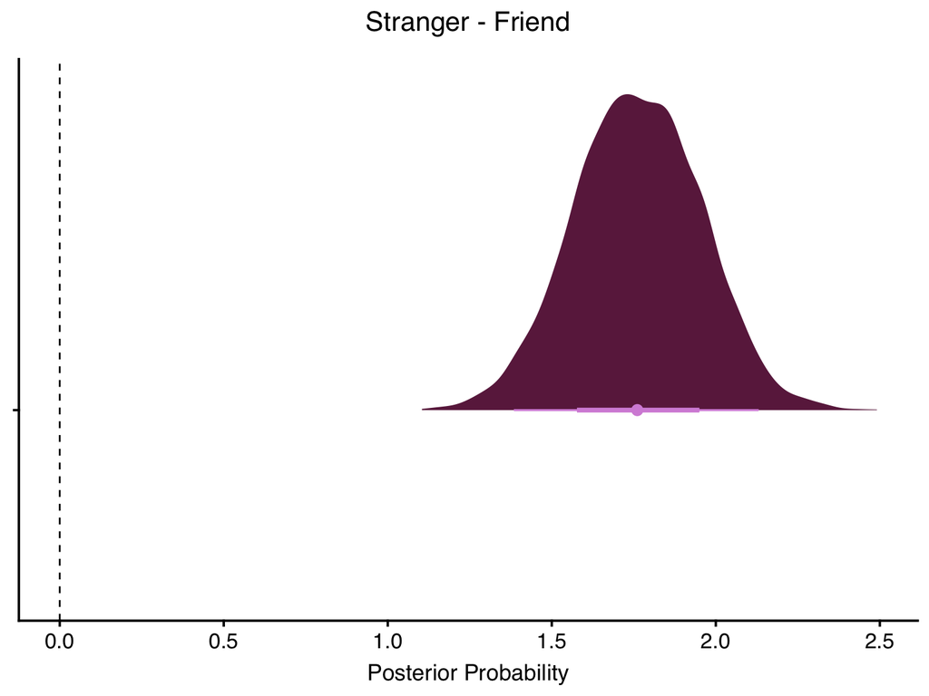

```r
extract(fit_S2)$b %>%
    melt(value.name = "post") %>%
    mutate(Var2 = ifelse(Var2 == 1, "Intercept", "")) %>%
    filter(Var2 != "Intercept") %>%
    ggplot(aes(x = post, y = Var2)) + stat_halfeye(fill = jcolors::jcolors(palette = "pal8")[6],
    color = jcolors::jcolors(palette = "pal8")[12]) + mytheme() + geom_vline(xintercept = 0,
    linetype = 2) + labs(y = NULL, x = "Posterior Probability", title = "Stranger - Friend")
```

## Beer on the Beach

To analyze the data from the third study (“Drink” scenarios) we fit a Bayesian gamma regression model. We estimate the mean offer difference between the “fancy resort hotel” and the “rundown grocery store” scenario.

#### (Short) Pilot Data

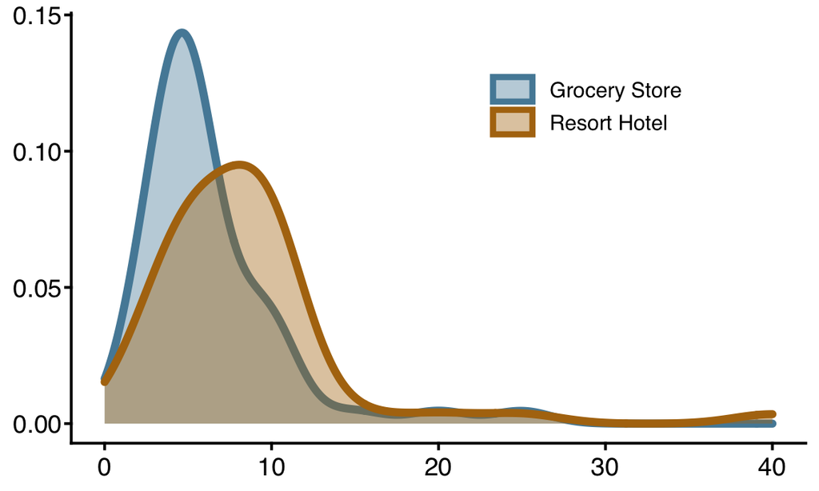

```r
# --------- Coding legend: --------- # -- Dependent Variable -- # response --
# Explanatory Variables -- # store: Resort hotel vs Grocery store

# Create dataframe scenario 3
data_s3 <- data_short_MA %>%
    select(subject, contains("C", ignore.case = FALSE)) %>%
    melt(id.var = "subject", variable.name = "store", value.name = "response") %>%
    mutate(store = ifelse(store == "C1_1", "Resort Hotel", "Grocery Store"), response = as.numeric(response))

data_s3 %>%
    ggplot(aes(response, fill = store, color = store)) + geom_density(alpha = 0.4,
    adjust = 1.5, size = 2) + mytheme() + theme(legend.position = c(0.7, 0.8)) +
    scale_fill_jcolors(palette = "pal6") + scale_color_jcolors(palette = "pal6") +
    # scale_y_continuous(labels=scales::percent, guide = 'prism_offset') +
scale_x_continuous(breaks = seq(0, 40, 10), limits = c(0, 40)) + labs(y = NULL, x = NULL)
```

#### Questions

You are on the beach on a hot day, and you would really like a cold bottle of beer. A friend offers to go buy the beer from [a fancy resort hotel / a small, run-down grocery store]. They ask how much you are willing to pay for the beer: they will only buy it if it costs as much or less than the price you state. You trust your friend, and there is no possibility of bargaining with the bartender.

What price do you tell them?

#### Stan Code

```stan
data {
  int<lower=1> N;  // total number of observations
  vector[N] Y;  // response variable
  int<lower=1> K;  // number of population-level effects
  matrix[N, K] X;  // population-level design matrix

  int prior_only;  // should the likelihood be ignored?
}

parameters {
  vector[K] b;  // population-level effects
  real<lower=0> shape;  // shape parameter
}

transformed parameters {
}

model {
  // likelihood including constants
  if (!prior_only) {
    // initialize linear predictor term
    vector[N] mu = X * b;
    for (n in 1:N) {
      // apply the inverse link function
      mu[n] = shape * exp(-(mu[n]));
    }
    target += gamma_lpdf(Y | shape, mu);
  }
  // priors including constants
  target += normal_lpdf(b | 0, 5);
  target += gamma_lpdf(shape | 0.01, 0.01);
}
```

```
data {
  int<lower=1> N;  // total number of observations
  vector[N] Y;  // response variable
  int<lower=1> K;  // number of population-level effects
  matrix[N, K] X;  // population-level design matrix

  int prior_only;  // should the likelihood be ignored?
}

parameters {
  vector[K] b;  // population-level effects
  real<lower=0> shape;  // shape parameter
}

transformed parameters {
}

model {
  // likelihood including constants
  if (!prior_only) {
    // initialize linear predictor term
    vector[N] mu = X * b;
    for (n in 1:N) {
      // apply the inverse link function
      mu[n] = shape * exp(-(mu[n]));
    }
    target += gamma_lpdf(Y | shape, mu);
  }
  // priors including constants
  target += normal_lpdf(b | 0, 5);
  target += gamma_lpdf(shape | 0.01, 0.01);
}
```

#### Fit

```r
# Create Stan Data
X <- model.matrix(~ store, data_s3)

#Stan Data
stan_data <- list(
  N = nrow(data_s3),
  Y = data_s3$response,
  X = X,
  K = ncol(X),

  N_sbj    = n_sbj,
  J_sbj    = data_s3$subject,

  prior_only = 0
)

# Fit the model
fit_S3 <- rstan::sampling(gamma_scenario_3,
                          iter = 2000,
                          cores = 4,
                          data = stan_data,
                          save_warmup = FALSE)
```

**Plot Model Posteriors**

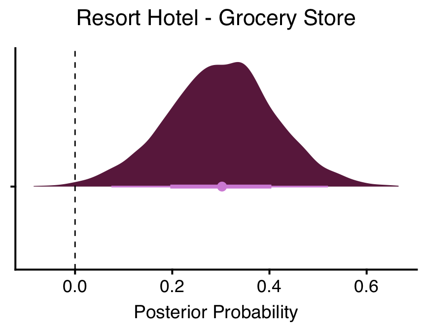

```r
draws <- extract(fit_S3)

draws$b %>%
    melt(value.name = "post") %>%
    mutate(Var2 = ifelse(Var2 == 1, "Intercept", "")) %>%
    filter(Var2 != "Intercept") %>%
    ggplot(aes(x = post, y = Var2)) + stat_halfeye(fill = jcolors::jcolors(palette = "pal8")[6],
    color = jcolors::jcolors(palette = "pal8")[12]) + mytheme() + geom_vline(xintercept = 0,
    linetype = 2) + labs(y = NULL, x = "Posterior Probability", title = "Resort Hotel - Grocery Store")
```

## Jacket-Calculator

We will analyze the data from the Jacket-Calculator study using a Bayesian binomial regression model in order to estimate the probability to respond ‘Yes’ in the two scenarios.

#### (Short) Pilot Data

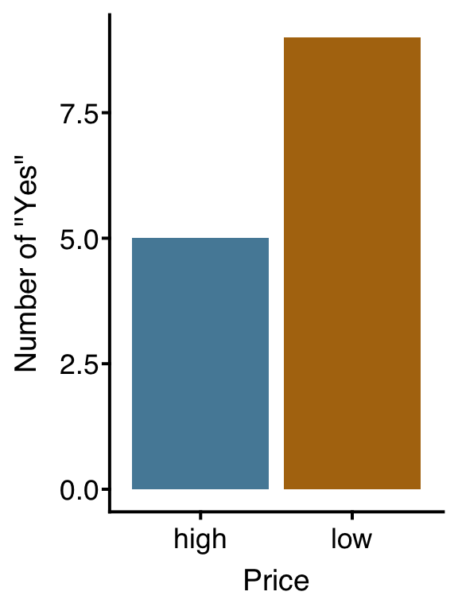

```r
# --------- Coding legend: --------- #
  # -- Dependent Variable -- #
  # response
  # -- Explanatory Variables -- #
  # store: Resort hotel vs Grocery store

  # Create dataframe scenario 3
  data_s4 <- data_short_MA %>%
    select(subject, contains('D', ignore.case = FALSE)) %>%
    rename(low_price2 = D3, low_price1 = D2_1,
           high_price2 = D4, high_price1 = D2_2) %>%
    melt(id.var='subject',
         variable.name='price',
         value.name='response') %>%
    mutate(price=ifelse(str_detect(price, 'low'), 'low', 'high'),
           response=ifelse(response=='No', 0, 1))

  data_s4 %>%
    filter(response==1) %>%
    group_by(price) %>%
    count(response, .drop = F) %>%
    ungroup() %>%
    ggplot(aes(price, n, fill=price)) +
    geom_bar(stat = "identity",
             # aes(y = (..count..)/sum(..count..)),
             position = position_dodge()) +
    mytheme() + theme(legend.position = 'none') +
    scale_fill_jcolors(palette = 'pal6') +
    scale_color_jcolors(palette = 'pal6') +
    # scale_y_continuous(labels=scales::percent, guide = "prism_offset") +
    labs(y='Number of "Yes"', x='Price')
```

#### Questions

You are about to purchase a jacket for [$125 / $15] and a Bluetooth speaker for [$15 / $125]. The salesman informs you that the speaker you wish to buy is on sale for [$10 / $120] at the other branch store, located 20 minutes away.

Would you make the trip to the other store? a) Yes a) No

Imagine that you are about to purchase a jacket for [$125 / $15] and a calculator for [$15 / $125]. The salesman informs you that the calculator you wish to buy is on sale for [$10 / $120] at the other branch store, located 20 minutes away.

Would you make the trip to the other store? a) Yes a) No

#### Stan Code

```r
bernoulli_scenario_4 <- rstan::stan_model("bernoulli_scenario_4.stan")
```

[output not shown]

```
data {
  int<lower=1> N;  // total number of observations
  int Y[N];  // response variable
  int<lower=1> K;  // number of population-level effects
  matrix[N, K] X;  // population-level design matrix

  int prior_only;  // should the likelihood be ignored?
}

parameters {
  vector[K] b;  // population-level effects
}

transformed parameters {
}

model {
  // likelihood including constants
  if (!prior_only) {
    vector[N] mu = X * b;
    target += bernoulli_logit_lpmf(Y | mu);
  }
  // priors including constants
  target += normal_lpdf(b | 0, 5);
}
```

#### Fit

```r
# Create Stan Data
X <- model.matrix(~ price, data_s4)

#Stan Data
stan_data <- list(
  N = nrow(data_s4),
  Y = data_s4$response,
  X = X,
  K = ncol(X),

  N_sbj    = n_sbj,
  J_sbj    = data_s4$subject,

  prior_only = 0
)

# Fit the model
fit_S4 <- rstan::sampling(bernoulli_scenario_4,
                          iter = 2000,
                          cores = 4,
                          save_warmup = FALSE,
                          data = stan_data,
                          save_warmup = FALSE)
```

**Plot Model Posteriors**

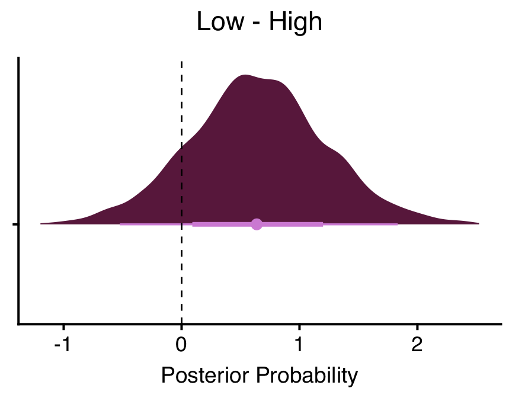

```r
extract(fit_S4)$b %>%
    melt(value.name = "post") %>%
    mutate(Var2 = ifelse(Var2 == 1, "Intercept", "")) %>%
    filter(Var2 != "Intercept") %>%
    ggplot(aes(x = post, y = Var2)) + stat_halfeye(fill = jcolors::jcolors(palette = "pal8")[6],
    color = jcolors::jcolors(palette = "pal8")[12]) + mytheme() + geom_vline(xintercept = 0,
    linetype = 2) + labs(y = NULL, x = "Posterior Probability", title = "Low - High")
```

## Lost Ticket

We analyze the data from the Lost Ticket study using a Bayesian binomial regression model in order to estimate the probability to respond ‘Yes’ in the two scenarios.

#### (Short) Pilot Data

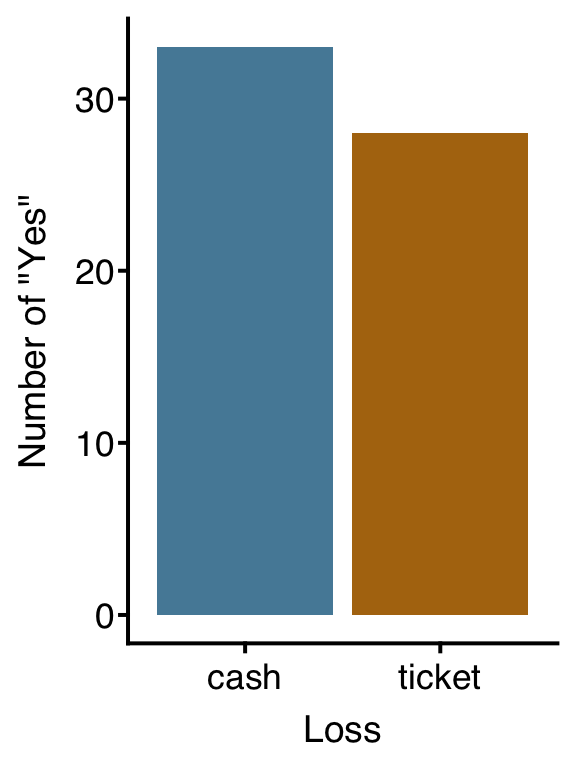

```r
# --------- Coding legend: --------- #
# -- Dependent Variable -- #
# response
# -- Explanatory Variables -- #
# loss: ticket vs cash

# Create dataframe scenario 3
data_s5 <- data_short_MA %>%
  select(subject, contains('E', ignore.case = FALSE)) %>%
  rename(ticket = E1,
         cash = E2) %>%
  melt(id.var='subject',
       variable.name='loss',
       value.name='response') %>%
  mutate(response=ifelse(response=='No', 0, 1))

data_s5 %>%
  filter(response==1) %>%
  group_by(loss) %>%
  count(response, .drop = F) %>%
  ungroup() %>%
  ggplot(aes(loss, n, fill=loss)) +
  geom_bar(stat = "identity",
           # aes(y = (..count..)/sum(..count..)),
           position = position_dodge()) +
  mytheme() + theme(legend.position = 'none') +
  scale_fill_jcolors(palette = 'pal6') +
  scale_color_jcolors(palette = 'pal6') +
  # scale_y_continuous(labels=scales::percent, guide = "prism_offset") +
  labs(y='Number of "Yes"', x='Loss')
```

#### Questions

Imagine you are on your way to a play with [a pair of tickets for which you have paid $40 / the intention of buying two tickets worth $40 in total]. On entering the theater, you discover that [you have lost the tickets / you have lost $40 in cash].

Would you pay $40 for another pair of tickets? a) Yes b) No

#### Stan Code

```
data {
  int<lower=1> N;  // total number of observations
  int Y[N];  // response variable
  int<lower=1> K;  // number of population-level effects
  matrix[N, K] X;  // population-level design matrix

  int prior_only;  // should the likelihood be ignored?
}

parameters {
  vector[K] b;  // population-level effects
}

transformed parameters {
}

model {
  // likelihood including constants
  if (!prior_only) {
    vector[N] mu = X * b;
    target += bernoulli_logit_lpmf(Y | mu);
  }
  // priors including constants
  target += normal_lpdf(b | 0, 5);
}
```

#### Fit

```r
# Create Stan Data
X <- model.matrix(~ loss, data_s5)

#Stan Data
stan_data <- list(
  N = nrow(data_s5),
  Y = data_s5$response,
  X = X,
  K = ncol(X),

  N_sbj    = n_sbj,
  J_sbj    = data_s3$subject,

  prior_only = 0
)

# Fit the model
fit_S5 <- rstan::sampling(bernoulli_scenario_4,
                          iter = 2000,
                          cores = 4,
                          save_warmup = FALSE,
                          data = stan_data,
                          save_warmup = FALSE)
```

**Plot Model Posteriors**

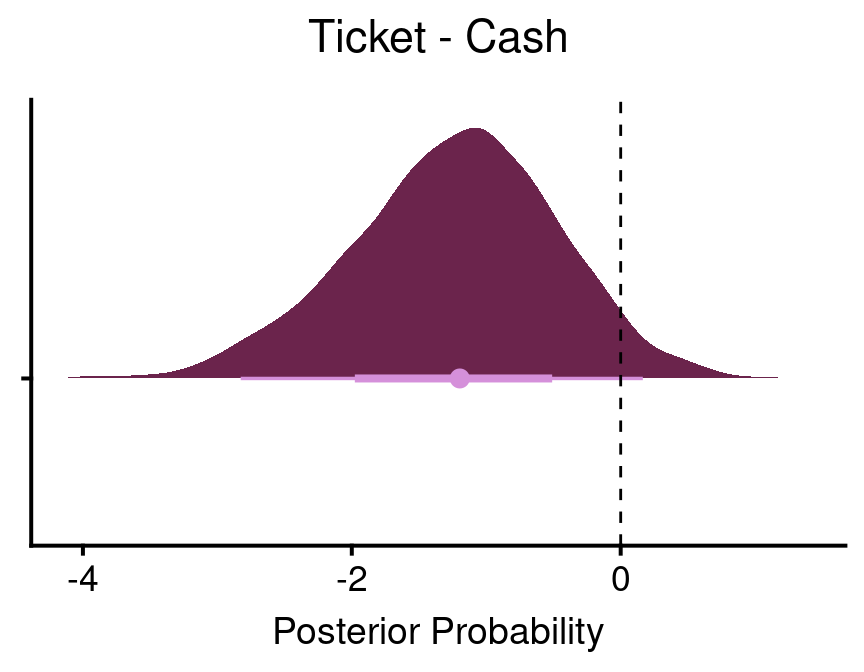

```r
extract(fit_S5)$b %>%
    melt(value.name = 'post') %>%
    mutate(Var2=ifelse(Var2==1, 'Intercept', '')) %>%
    filter(Var2!='Intercept') %>%
    ggplot(aes(x = post, y = Var2)) +
    stat_halfeye(fill = jcolors::jcolors(palette = "pal8")[6],
                 color = jcolors::jcolors(palette = "pal8")[12]) +
    mytheme() + geom_vline(xintercept = 0, linetype = 2) +
    labs(y = NULL, x = "Posterior Probability", title='Ticket - Cash')
```